# LinearRegression

```python
import numpy as np
import pandas as pd
import matplotlib.pyplot as plt
%matplotlib inline
```

```python
a = np.array([[3,3.5,2],[3.2,3.6,3],[6,7,4]])
a
np.linalg.matrix_rank(a)
```

```
2
```

```python
y = 2*x + 2
y - 2 = 2x
(y-2)/2 = x
```

```python
A.B = C.D
求A
矩阵没有除法
B. B^-1 = I
任何矩阵乘于单位矩阵等于它本身
A.I = A
左右两边右边乘于B矩阵的逆,就可以把B消掉.
A.B.B^-1 = C.D.B^-1
A = C.D.B^-1
```

```python
# 不是所有矩阵都有逆, 奇异矩阵就没有逆
np.linalg.inv(a)
```

[output not shown]

```python
n = np.array([[1,2,3], [2,3,4], [4,5,6]])
np.linalg.inv(n)
```

[output not shown]

```python
np.linalg.matrix_rank(n)
```

```
2
```

```python
n = np.array([[1,3,5], [1,2,3], [3,5,6]])
np.linalg.inv(n)
```

```
array([[-3.,  7., -1.],
       [ 3., -9.,  2.],
       [-1.,  4., -1.]])
```

```python
以一个具体的例子来看。假设一帮孩子和家长出去旅游，去程坐的是bus，小孩票价为3元，家长票价为3.2元；回程坐的是Train，小孩票价为3.5元，家长票价为3.6元。
坐bus总共花费118.4元,坐train总共花费135.2元,问题是分别求小孩和家长的人数。我们就可以用下列矩阵求之。
假设 小孩 x, 大人 y
3*x + 3.2*y = 118.4
3.5*x + 3.6*y = 135.2
```

```python
[[3, 3.2],
[3.5, 3.6]] . [[x], [y]] = [[118.4], [135.2]]
```

```python
求 [[3, 3.2], 的逆
[3.5, 3.6]]
```

```python
price = np.array([[3, 3.2],
[3.5, 3.6]])
price
```

```
array([[3. , 3.2],
       [3.5, 3.6]])
```

```python
price_inv = np.linalg.inv(price)
price_inv
```

```
array([[-9.  ,  8.  ],
       [ 8.75, -7.5 ]])
```

```python
np.dot(price_inv, np.array([[118.4], [135.2]]))
```

```
array([[16.],
       [22.]])
```

# 线性回归

## 【关键词】最小二乘法，线性

## 一、普通线性回归

### 1、原理

分类的目标变量是标称型数据，而回归将会对连续型的数据做出预测。

应当怎样从一大堆数据里求出回归方程呢？

假定输人数据存放在矩阵X中，而回归系数存放在向量W中。那么对于给定的数据X1, 预测结果将会通过

Y=X*W

给出。现在的问题是，手里有一些X和对应的Y,怎样才能找到W呢？

一个常用的方法就是找出使误差最小的W。这里的误差是指预测Y值和真实Y值之间的差值，使用该误差的简单累加将使得正差值和负差值相互抵消，所以我 们采用平方误差。

最小二乘法

例如有下面一张图片：

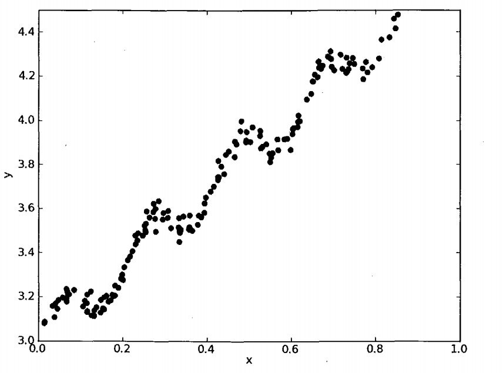

求回归曲线，得到：

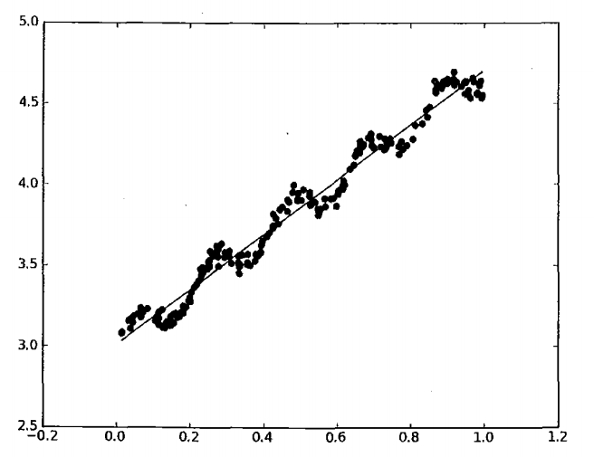

### 2、实例

导包

```python
from sklearn.linear_model import LinearRegression
```

获取糖尿病数据

```python
from sklearn.datasets import load_diabetes
```

```python
diabetes = load_diabetes()
```

```python
diabetes
```

[output not shown]

[output cut: 12 more lines]

```
         94., 183.,  66., 173.,  72.,  49.,  64.,  48., 178., 104., 132.,
        220.,  57.]),
 'DESCR': '.. _diabetes_dataset:\n\nDiabetes dataset\n----------------\n\nTen baseline variables, age, sex, body mass index, average blood\npressure, and six blood serum measurements were obtained for each of n =\n442 diabetes patients, as well as the response of interest, a\nquantitative measure of…
 'feature_names': ['age',
  'sex',
  'bmi',
  'bp',
  's1',
  's2',
  's3',
  's4',
  's5',
  's6'],
 'data_filename': 'd:\\1903\\.venv\\lib\\site-packages\\sklearn\\datasets\\data\\diabetes_data.csv.gz',
 'target_filename': 'd:\\1903\\.venv\\lib\\site-packages\\sklearn\\datasets\\data\\diabetes_target.csv.gz'}
```

```python
data = diabetes['data']
target = diabetes['target']
feature_names = diabetes['feature_names']
```

```python
from pandas import DataFrame
```

```python
df = DataFrame(data=data, columns=feature_names)
df.head()
# bmi = body mass index
# bp blood pressure
```

|  | age | sex | bmi | bp | s1 | s2 | s3 | s4 | s5 | s6 |
| --- | --- | --- | --- | --- | --- | --- | --- | --- | --- | --- |
| 0 | 0.038076 | 0.050680 | 0.061696 | 0.021872 | -0.044223 | -0.034821 | -0.043401 | -0.002592 | 0.019908 | -0.017646 |
| 1 | -0.001882 | -0.044642 | -0.051474 | -0.026328 | -0.008449 | -0.019163 | 0.074412 | -0.039493 | -0.068330 | -0.092204 |
| 2 | 0.085299 | 0.050680 | 0.044451 | -0.005671 | -0.045599 | -0.034194 | -0.032356 | -0.002592 | 0.002864 | -0.025930 |
| 3 | -0.089063 | -0.044642 | -0.011595 | -0.036656 | 0.012191 | 0.024991 | -0.036038 | 0.034309 | 0.022692 | -0.009362 |
| 4 | 0.005383 | -0.044642 | -0.036385 | 0.021872 | 0.003935 | 0.015596 | 0.008142 | -0.002592 | -0.031991 | -0.046641 |

抽取训练数据和预测数据

```python
from sklearn.model_selection import train_test_split
```

```python
data.shape
```

```
(442, 10)
```

```python
X_train, X_test, y_train, y_test = train_test_split(data, target, test_size=42)
```

```python
linear = LinearRegression()
linear.fit(X_train, y_train)
```

[output not shown]

```python
linear.score(X_train, y_train)
```

```
0.5210783728800357
```

```python
linear.predict(X_test)
```

```
array([ 63.28672399, 155.95342174, 187.61937733, 186.39315312,
       127.74991743,  75.08268788,  66.05106167, 113.05517996,
        63.07608437, 131.76783096,  82.14047198,  51.62263891,
        76.71303807, 190.06314922, 209.41263471, 160.21572443,
       163.4011659 , 119.94200382, 261.37753292, 168.16082482,
       161.30690199, 218.1506794 , 204.40280265,  79.51017393,
       132.924167  , 211.58260908,  71.48420087, 168.72746347,
        99.70374085, 257.41139829, 146.29551347, 120.92075479,
        62.08395598, 194.95796286, 183.47401923,  84.83667438,
       181.15386518, 121.2438309 , 105.09248196, 239.30567965,
       290.38884677, 155.33567804])
```

```python
# 线性方程的系数
linear.coef_
```

```
array([  -9.67577155, -244.22300365,  522.19863005,  308.40820014,
       -806.30976891,  456.31867573,  143.8884171 ,  244.47131165,
        726.72035246,  118.30543126])
```

```python
linear.intercept_
```

```
151.65470141168322
```

```python
y_test
```

```
array([ 72., 200., 164.,  67.,  42.,  89., 158.,  88.,  77.,  49.,  98.,
        90.,  55., 163., 297.,  94., 265., 253., 303., 258., 252., 279.,
       109.,  51., 170., 166.,  75., 220.,  69., 273., 172.,  89.,  52.,
       233., 144.,  71.,  84., 191., 142., 252., 270., 109.])
```

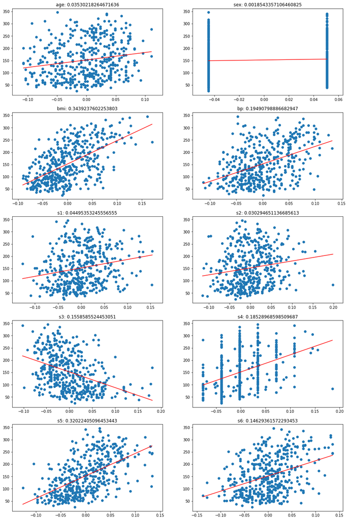

```python
# 研究单个特征对结果的影响
# 单独取出每个特征来研究对结果的影响
# 5行2列
plt.figure(figsize=(2* 8, 5*5))
for i, col in enumerate(df.columns):
    X_train = df[[col]]
    linear = LinearRegression()
    score = linear.fit(X_train, target).score(X_train, target)
    # 以训练数据为X轴, 标记为Y轴画散点图
    axes = plt.subplot(5,2,i+1)
    axes.scatter(X_train, target)
    # y = wx + b
    x = np.linspace(X_train.min(), X_train.max(), 100)
    y = linear.coef_ * x + linear.intercept_
    axes.plot(x,y, c='r')
    axes.set_title(col + ': ' + str(score))
```

创建数学模型

第一步：训练

第二步：预测

## 二、岭回归

### 1、原理

缩减系数来“理解”数据

如果数据的特征比样本点还多应该怎么办？是否还可以使用线性回归和之前的方法来做预测？

答案是否定的，即不能再使用前面介绍的方法。这是因为输入数据的矩阵X不是满秩矩阵。非满秩矩阵在求逆时会出现问题。

为了解决这个问题，统计学家引入了岭回归（ridge regression)的概念

```python
ridge
```

```python
30个样本, 50个特征
```

```python
# 50个样本, 200个特征
X = np.random.randn(50,200)
y = np.random.randn(50)
```

```python
linear = LinearRegression()
linear.fit(X, y)
```

```
LinearRegression(copy_X=True, fit_intercept=True, n_jobs=None, normalize=False)
```

```python
linear.score(X,y)
```

```
1.0
```

```python
linear.coef_
```

```
array([ 0.03595726, -0.0448257 , -0.03188724, -0.02328296,  0.04694029,
       -0.00774192,  0.04783527,  0.03981391, -0.02322086,  0.00322679,
        0.0831673 , -0.02682158, -0.00079808,  0.04248429,  0.03049738,
       -0.04922527,  0.0106654 , -0.00481602, -0.01307311, -0.01122849,
        0.04028575,  0.0459941 , -0.02188211, -0.06334038, -0.02369834,
       -0.03906074, -0.02119672, -0.01199379, -0.04661094,  0.05495849,
       -0.04933867,  0.06582286, -0.01402159,  0.02393151, -0.0168221 ,
       -0.00031275, -0.02525295, -0.0155676 , -0.04049719, -0.01618954,
        0.02454055, -0.0429669 ,  0.04023918,  0.07761166, -0.01313653,
        0.06746674,  0.03059033,  0.00032059,  0.02382187,  0.01340047,
        0.03594147, -0.05614811, -0.00633306,  0.04330977,  0.04537196,
       -0.01212349, -0.03451009,  0.05535586, -0.09757387,  0.02472596,
        0.0216132 ,  0.03449885,  0.0181237 , -0.02561646, -0.02202883,
       -0.02300779,  0.05018078,  0.05365364,  0.02910427, -0.08533104,
       -0.07221241, -0.02353849, -0.02752997,  0.08615929,  0.01288456,
        0.01119768, -0.02142957, -0.00191346, -0.01120979,  0.05068941,
       -0.02927538, -0.0936541 ,  0.00850195, -0.01160752,  0.01368359,
        0.01982322,  0.08101076,  0.00489232,  0.04595664,  0.04799939,
       -0.03660139,  0.02898714,  0.02948342, -0.00467407,  0.05267814,
       -0.02204316, -0.03324253, -0.00472009, -0.05584161,  0.02419279,
        0.01310341, -0.03122147, -0.02037798, -0.02883424, -0.04069151,
        0.038899  , -0.01630349, -0.01227819,  0.06972189,  0.00256392,
       -0.0820178 ,  0.01073056, -0.08410325,  0.03108082,  0.05898147,
       -0.04907061, -0.03403901,  0.02685117,  0.05880076,  0.06601974,
        0.05223612,  0.00412999, -0.06047325,  0.02430688, -0.08187047,
       -0.05020976, -0.01531433, -0.01936507, -0.03838163, -0.01260722,
       -0.05500058, -0.0381242 , -0.08778071, -0.04236694, -0.00315734,
        0.12050913,  0.06443328, -0.01428292,  0.00148509, -0.03546172,
        0.0614919 , -0.03400165,  0.03024327,  0.02572146,  0.03122691,
        0.03780296, -0.09221189,  0.00797021, -0.01946107, -0.08083087,
        0.08111427, -0.04729628,  0.0293769 , -0.02985096, -0.03818533,
       -0.00845622,  0.02052887,  0.04522093, -0.03563528, -0.04679615,
        0.03759992, -0.01368844, -0.1100313 , -0.00229525,  0.0587656 ,
       -0.00407182, -0.04942417,  0.02308554, -0.05735823,  0.01205534,
        0.00204615, -0.06093067, -0.0065952 , -0.05221781,  0.00556877,
        0.03001362,  0.09257372,  0.0388829 , -0.06562333,  0.0073091 ,
        0.06180119,  0.00772443, -0.01069268, -0.01917125,  0.00285903,
       -0.04417172, -0.04961415,  0.04074965, -0.00342964,  0.03222028,
        0.00382448, -0.03039625, -0.05114194,  0.05962452,  0.00376152,
        0.06786613, -0.03462288, -0.04616756, -0.12253161, -0.00593231])
```

```python
from sklearn.linear_model import Ridge
```

```python
# 超参数 alpha
ridge = Ridge(alpha=1)
ridge.fit(X, y)
ridge.score(X,y)
```

```
0.9999223946466052
```

```python
ridge.score(X,y)
```

```
0.9999223946466052
```

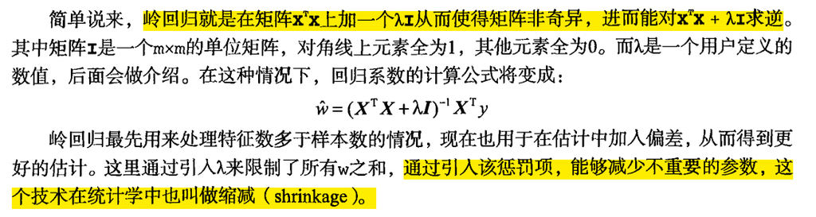

```python
x1 + 3x2 + 5x3
x1 + 2x2 + 3x3
2x1 + 4x2 + 6x3
```

```python
1   3   5              0.001   0   0        1.001  3   5
1   2   3   +          0   0.001   0   ->   1    2.001 3
2   4   6              0   0   0.001        2   4    6.001
```

```python
n = np.array([[1,3,5], [1,2,3], [2,4,6]])
n
```

```
array([[1, 3, 5],
       [1, 2, 3],
       [2, 4, 6]])
```

```python
np.linalg.inv(np.dot(n.T, n))
```

[output not shown]

```python
np.linalg.inv(np.array([[1.001, 3, 5], [1, 2.001, 3], [2, 4, 6.001]]))
```

```
array([[-1.60308588e+00, -4.00120297e+02,  2.01362493e+02],
       [ 2.00360689e-01,  8.00040032e+02, -4.00120297e+02],
       [ 4.00721379e-01, -3.99919936e+02,  1.99759407e+02]])
```

```python
二阶正则
```

缩减方法可以去掉不重要的参数，因此能更好地理解数据。此外，与简单的线性回归相比，缩减法能取得更好的预测效果。

#### 归纳总结

1.岭回归可以解决特征数量比样本量多的问题

2.岭回归作为一种缩减算法可以判断哪些特征重要或者不重要，有点类似于降维的效果

3.缩减算法可以看作是对一个模型增加偏差的同时减少方差

岭回归用于处理下面两类问题：

1.数据点少于变量个数

2.变量间存在共线性（最小二乘回归得到的系数不稳定，方差很大）

### 岭回归系数研究

```python
X = 1 / (np.arange(1,11) + np.arange(10).reshape(10,1))
```

```python
X.shape
```

```
(10, 10)
```

```python
y = np.arange(1,11)
```

```python
np.arange(10).reshape(10,1)
```

```
array([[0],
       [1],
       [2],
       [3],
       [4],
       [5],
       [6],
       [7],
       [8],
       [9]])
```

```python
np.linspace()
```

```python
# 对数等分
np.logspace()
```

```python
np.log(np.e)
```

```
1.0
```

```python
np.e
```

```
2.718281828459045
```

```python
np.log10(100)
```

```
2.0
```

```python
# 对数等分
alphas = np.logspace(-2, -10, 200)
```

```python
ridge.coef_
```

```
array([ 0.03758669, -0.04621425, -0.03176075, -0.02406154,  0.05097292,
       -0.01069723,  0.0512653 ,  0.04472867, -0.02528287,  0.00616011,
        0.08313961, -0.02497403, -0.00019417,  0.04218056,  0.03144867,
       -0.05047865,  0.01055109, -0.00494304, -0.01316586, -0.01460431,
        0.04136379,  0.04500026, -0.02295326, -0.06273457, -0.02340097,
       -0.03567846, -0.02266689, -0.01035996, -0.04611141,  0.04769786,
       -0.05087162,  0.06542555, -0.01398098,  0.0256838 , -0.01572113,
       -0.0008934 , -0.02486733, -0.01314872, -0.03923905, -0.0156049 ,
        0.02499019, -0.04137378,  0.03617952,  0.07727787, -0.01461826,
        0.0667911 ,  0.03004093, -0.00200044,  0.02351512,  0.01187697,
        0.03585083, -0.05532031, -0.00895501,  0.04399024,  0.04572046,
       -0.01000462, -0.03291196,  0.05498513, -0.09472662,  0.02385879,
        0.0210548 ,  0.03357361,  0.01638697, -0.02706866, -0.02160073,
       -0.02368464,  0.05061293,  0.05429942,  0.02855755, -0.08242934,
       -0.07070123, -0.02471104, -0.02598148,  0.08386568,  0.01315782,
        0.01145264, -0.02103465, -0.00221336, -0.01096025,  0.05028349,
       -0.02976071, -0.09254724,  0.00799318, -0.01076682,  0.0127129 ,
        0.02010863,  0.08010667,  0.00503326,  0.0451308 ,  0.04591351,
       -0.03610554,  0.02891089,  0.02927236, -0.00452889,  0.05382544,
       -0.02286143, -0.03190543, -0.00607677, -0.05463888,  0.02314313,
        0.01427386, -0.03186849, -0.02011229, -0.02923687, -0.04148758,
        0.03722831, -0.01480835, -0.01337052,  0.06864315,  0.0005459 ,
       -0.08124012,  0.01126225, -0.08262939,  0.03026525,  0.05894039,
       -0.04830293, -0.03472232,  0.02884491,  0.05848609,  0.06563837,
        0.05120423,  0.00593823, -0.06009544,  0.0231744 , -0.08128626,
       -0.05230403, -0.01533881, -0.01955645, -0.03804771, -0.01234099,
       -0.05413547, -0.03826235, -0.08614788, -0.04248579, -0.00358085,
        0.11863838,  0.0636141 , -0.01353781,  0.00098859, -0.03708749,
        0.05809601, -0.03412129,  0.03028703,  0.02492885,  0.03022659,
        0.03745943, -0.09068253,  0.00886261, -0.01918264, -0.08091578,
        0.07918399, -0.04594904,  0.03137751, -0.02997613, -0.0381291 ,
       -0.00679647,  0.01839039,  0.04407597, -0.03420467, -0.04813985,
        0.03722457, -0.0116798 , -0.10767067, -0.00297403,  0.05824879,
       -0.00485789, -0.04973396,  0.02257516, -0.05507496,  0.00945748,
        0.00221529, -0.05922601, -0.00857875, -0.05018294,  0.00533995,
        0.02702926,  0.09184637,  0.03879876, -0.06709251,  0.0071992 ,
        0.0607358 ,  0.00781738, -0.00906144, -0.01946765,  0.00252179,
       -0.04251736, -0.04999586,  0.03825334, -0.00524996,  0.03108963,
        0.0032181 , -0.02936661, -0.04880183,  0.0573615 ,  0.00230191,
        0.06755704, -0.03592972, -0.04512676, -0.12097144, -0.0075155 ])
```

```python
ridge.intercept_
```

```
-0.01724765065678964
```

```python
ridge = Ridge()
coefs = []
for alpha in alphas:
    ridge.set_params(alpha=alpha)
    ridge.fit(X,y)
    coef = ridge.coef_
    coefs.append(coef)
```

```python
len(coefs)
```

```
200
```

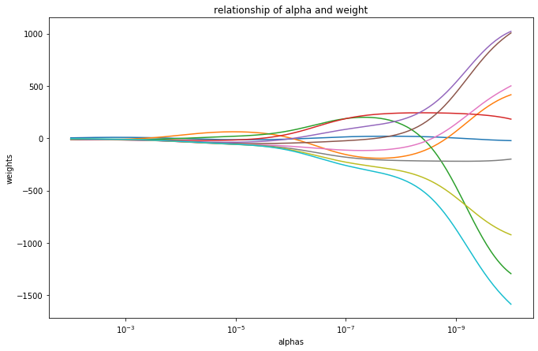

```python
plt.figure(figsize=(11,7))
plt.plot(alphas, coefs)
plt.xscale('log')
xmin, xmax = plt.xlim()
plt.xlim(xmin=xmax, xmax=xmin)
plt.xlabel('alphas')
plt.ylabel('weights')
plt.title('relationship of alpha and weight')
```

### 2、实例

岭回归一般用在样本值不够的时候

```python
ridge = Ridge(0.001)
ridge.fit(data, target).score(data, target)
```

```
0.5177078692545862
```

```python
ridge.score(data, target)
```

```
0.5177078692545862
```

```python
linear = LinearRegression()
linear.fit(data, target).score(data, target)
```

```
0.5177494254132934
```

使用岭回归

## 三、lasso回归

### 1、原理

【拉格朗日乘数法】

在lambda足够小的时候，一些系数会因此被迫缩减到0

```python
lasso的lambda叫做一阶正则
```

```python
from sklearn.linear_model import Lasso
```

```python
lasso = Lasso(alpha=0.01)
lasso.fit(X,y).score(X,y)
```

```
0.9926995482582132
```

### 2、实例

## 四、普通线性回归、岭回归与lasso回归比较

```python
X = np.random.randn(50, 200)
coef = np.random.randn(200)
y = np.dot(X, coef)# y = θX
```

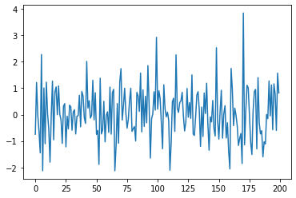

```python
plt.plot(coef)
```

```python
linear = LinearRegression()
linear.fit(X, y)
```

```
LinearRegression(copy_X=True, fit_intercept=True, n_jobs=None, normalize=False)
```

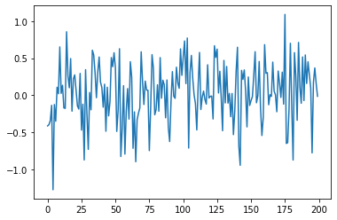

```python
plt.plot(linear.coef_)
```

```python
import random
random.shuffle()
```

```python
index = np.arange(0,200)
np.random.shuffle(index)
```

```python
index
```

```
array([ 88,  31, 129,  12,  19, 165, 121,   0, 169,  22, 198,  90,  89,
        13,  77,  87, 186, 170,  25, 149, 137, 151, 164,  56,  27,  35,
       108, 195,  26,  63,   4,  52, 193, 127, 173, 102,  44, 180, 187,
       101,  85,  74, 179,  37,  80, 166,  58, 114,  16,  28,  23,  50,
        75,   7,  82, 175,  48, 196, 154,  97, 145,  18, 152,  29, 120,
       161, 181,  93, 153, 178,  81, 144, 182,  17, 183,  47, 116, 194,
       115, 136, 159, 142, 139, 105,  70, 150,   6,  14,  40,  59, 109,
        15, 123,  11,  33,  68,  51,   3,  67,  46, 168, 113, 174,  62,
        34,  84, 110, 112,  91,  54,  39,  41, 122,  92, 131, 124,   5,
       162,  57,  86,  96,  98, 199, 148, 128,  53,  69, 146, 140, 125,
         9, 176, 163,  24,  95,  61, 188, 133, 111, 104,  66, 126, 117,
        49, 143, 130, 100,  64,  38, 191,  36, 103, 107,  71, 167, 141,
       156,  10, 134,  72, 135, 155, 147, 160,  99,   2, 192, 197, 106,
        94, 138,  20,  30, 119,  76,  83, 185, 184, 177,   8,  43, 171,
        79,  32, 132, 189, 172,  55, 118,  78, 157,  73,  65,  60,  21,
        45,  42, 190,   1, 158])
```

```python
coef[index[:190]] = 0
```

```python
y = np.dot(X, coef)
```

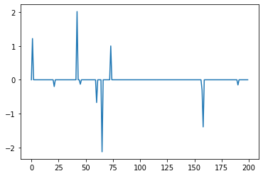

```python
plt.plot(coef)
```

```python
linear = LinearRegression()
linear.fit(X, y)
linear_coef = linear.coef_
```

```python
ridge = Ridge(alpha=0.1)
ridge.fit(X,y)
ridge_coef = ridge.coef_
```

```python
lasso = Lasso(alpha=0.01, max_iter=10000)
lasso.fit(X, y)
lasso_coef = lasso.coef_
```

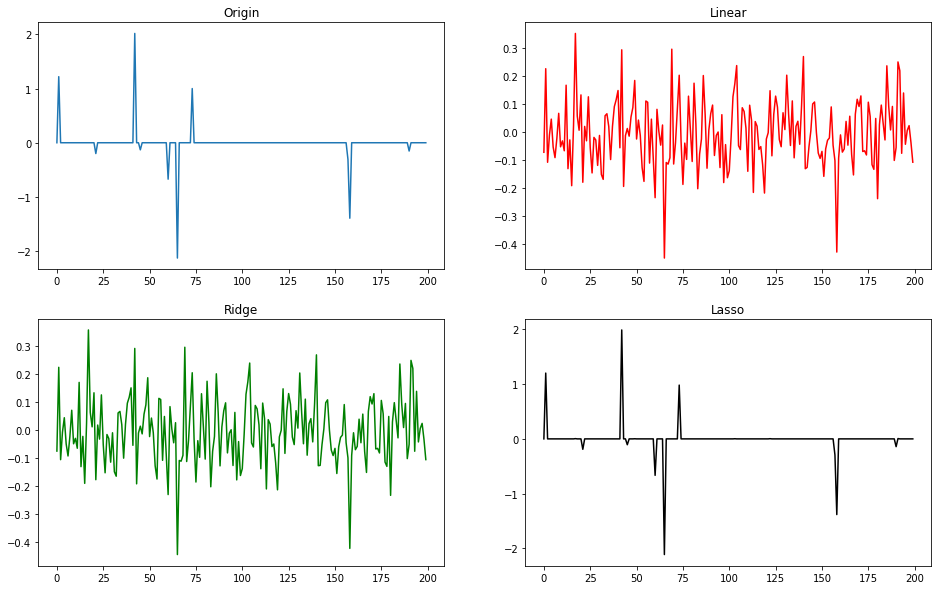

```python
plt.figure(figsize=(2* 8, 2* 5))
axes1 = plt.subplot(2,2,1)
axes1.plot(coef)
axes1.set_title('Origin')

axes2 = plt.subplot(2,2,2)
axes2.plot(linear_coef, c='r')
axes2.set_title('Linear')

axes3 = plt.subplot(2,2,3)
axes3.plot(ridge_coef, c='g')
axes3.set_title('Ridge')

axes4 = plt.subplot(2,2,4)
axes4.plot(lasso_coef, c='k')
axes4.set_title('Lasso')
```

训练数据和测试数据

分别使用线性回归，岭回归，Lasso回归进行数据预测

数据视图，此处获取各个算法的训练数据的coef_:系数

## 五、练习

### 1、使用多种方法对boston数据集进行回归，画出回归图像，并比较多种回归方法的效果

```
from sklearn.datasets import load_boston
boston = load_boston()
x = boston.data
y = boston.target
```

```python
from sklearn.datasets import load_boston
```

```python
boston = load_boston()
data = boston['data']
feature_names = boston['feature_names']
```

```python
df = DataFrame(data=data, columns=feature_names)
df.head()
```

|  | CRIM | ZN | INDUS | CHAS | NOX | RM | AGE | DIS | RAD | TAX | PTRATIO | B | LSTAT |
| --- | --- | --- | --- | --- | --- | --- | --- | --- | --- | --- | --- | --- | --- |
| 0 | 0.00632 | 18.0 | 2.31 | 0.0 | 0.538 | 6.575 | 65.2 | 4.0900 | 1.0 | 296.0 | 15.3 | 396.90 | 4.98 |
| 1 | 0.02731 | 0.0 | 7.07 | 0.0 | 0.469 | 6.421 | 78.9 | 4.9671 | 2.0 | 242.0 | 17.8 | 396.90 | 9.14 |
| 2 | 0.02729 | 0.0 | 7.07 | 0.0 | 0.469 | 7.185 | 61.1 | 4.9671 | 2.0 | 242.0 | 17.8 | 392.83 | 4.03 |
| 3 | 0.03237 | 0.0 | 2.18 | 0.0 | 0.458 | 6.998 | 45.8 | 6.0622 | 3.0 | 222.0 | 18.7 | 394.63 | 2.94 |
| 4 | 0.06905 | 0.0 | 2.18 | 0.0 | 0.458 | 7.147 | 54.2 | 6.0622 | 3.0 | 222.0 | 18.7 | 396.90 | 5.33 |

### 2、预测鲍鱼的年龄

abalone.txt